# Replication Study of Anti-Immigrant Rhetoric and ICE Reporting Interest: Evidence from a Large-Scale Study of Web Search Data

Yinuo Xu (New York University), Phuong (Jane) Le (Fordham Univeristy)

2024-06-28 15:06:41.442521

```r
# Load necessary libraries
library(tidyverse)
library(ggplot2)
library(dplyr)
library(tidyr)
library(lubridate)
library(gt)
library(broom)
```

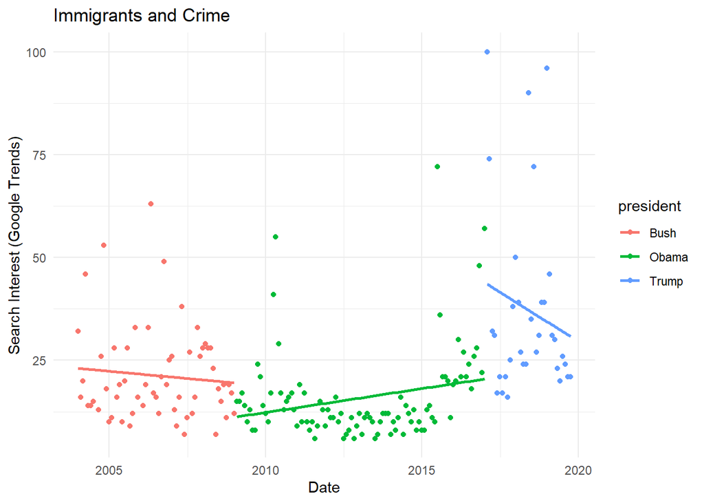

```r
# Function to assign president based on date
assign_president <- function(date) {
  if (date < as.Date("2009-01-20")) {
    return("Bush")
  } else if (date < as.Date("2017-01-20")) {
    return("Obama")
  } else {
    return("Trump")
  }
}

immigrants_crime <- read_csv("google_trends_crime.csv") %>%
  mutate(
    hits = as.numeric(search),
    date = as.Date(paste0(year, "-", month, "-01")),
    terms = "Crime"
  ) %>%
  filter(!is.na(date) & hits > 0) %>%
  mutate(president = sapply(date, assign_president))%>%
  mutate(period = case_when(
    date < as.Date("2015-06-01") ~ "Pre-Campaign",
    date >= as.Date("2015-06-01") & date < as.Date("2017-01-01") ~ "Campaign",
    date >= as.Date("2017-01-01") ~ "Post-Inauguration"
  )) %>%
  mutate(period = factor(period, levels = c("Pre-Campaign", "Campaign", "Post-Inauguration")))


immigrants_welfare <- read_csv("google_trends_welfare.csv") %>%
  mutate(
    hits = as.numeric(search),
    date = as.Date(paste0(year, "-", month, "-01")),
    terms = "Welfare"
  ) %>%
  filter(!is.na(date) & hits > 0) %>%
  mutate(president = sapply(date, assign_president))%>%
  mutate(period = case_when(
    date < as.Date("2015-06-01") ~ "Pre-Campaign",
    date >= as.Date("2015-06-01") & date < as.Date("2017-01-01") ~ "Campaign",
    date >= as.Date("2017-01-01") ~ "Post-Inauguration"
  )) %>%
  mutate(period = factor(period, levels = c("Pre-Campaign", "Campaign", "Post-Inauguration")))


report_immigrants <- read_csv("google_trends_report.csv") %>%
  mutate(
    hits = as.numeric(search),
    date = as.Date(paste0(year, "-", month, "-01")),
    terms = "Report"
  ) %>%
  filter(!is.na(date) & hits > 0) %>%
  mutate(president = sapply(date, assign_president))%>%
  mutate(period = case_when(
    date < as.Date("2015-06-01") ~ "Pre-Campaign",
    date >= as.Date("2015-06-01") & date < as.Date("2017-01-01") ~ "Campaign",
    date >= as.Date("2017-01-01") ~ "Post-Inauguration"
  )) %>%
  mutate(period = factor(period, levels = c("Pre-Campaign", "Campaign", "Post-Inauguration")))

 ggplot(immigrants_crime, aes(x = date, y = hits, color = president)) +
  geom_point() +
  geom_smooth(method = "lm", se = FALSE) +
  geom_point(alpha = 0.3) +
  labs(title = "Immigrants and Crime",
       x = "Date",
       y = "Search Interest (Google Trends)") +
  theme_minimal()
```

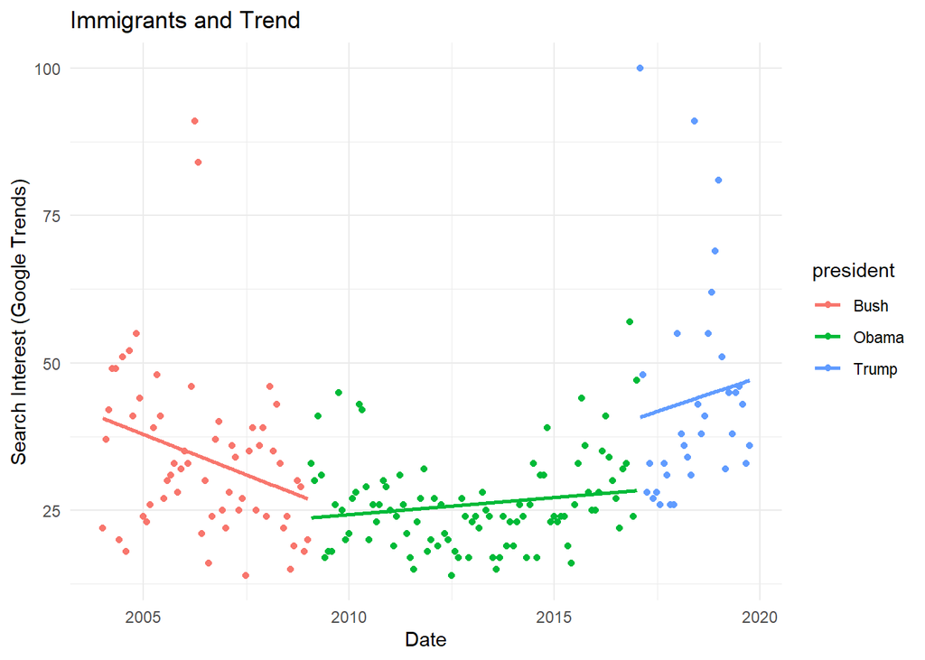

```r
  ggplot(immigrants_welfare, aes(x = date, y = hits, color = president)) +
  geom_point() +
  geom_smooth(method = "lm", se = FALSE) +
  geom_point(alpha = 0.3) +
  labs(title = "Immigrants and Trend",
       x = "Date",
       y = "Search Interest (Google Trends)") +
  theme_minimal()
```

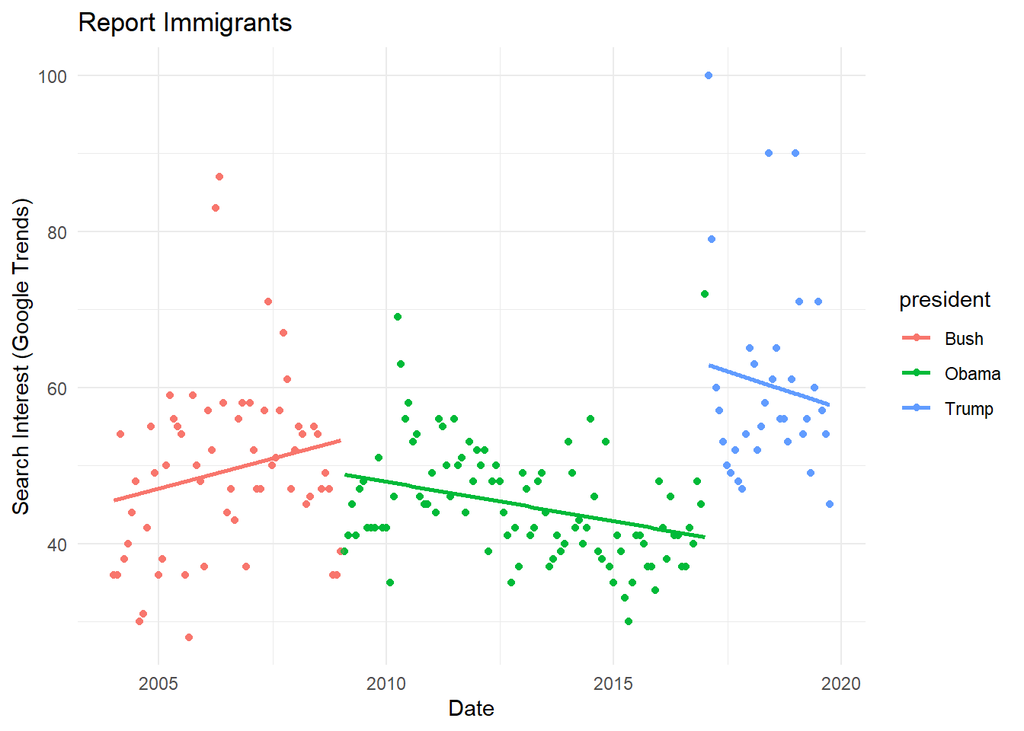

```r
   ggplot(report_immigrants, aes(x = date, y = hits, color = president)) +
  geom_point() +
  geom_smooth(method = "lm", se = FALSE) +
  geom_point(alpha = 0.3) +
  labs(title = "Report Immigrants",
       x = "Date",
       y = "Search Interest (Google Trends)") +
  theme_minimal()
```

The graphs produced are similar to the ones displayed in paper.

```r
# Combine
combined_data <- bind_rows(immigrants_crime, immigrants_welfare, report_immigrants)

# Set Obama as the baseline
combined_data$president <- relevel(factor(combined_data$president), ref = "Obama")

# Define the linear model function
run_regression <- function(data) {
  lm(hits ~ date + president, data = data)
}


# Run regression
crime_model <- run_regression(filter(combined_data, terms == "Crime"))
welfare_model <- run_regression(filter(combined_data, terms == "Welfare"))
report_model <- run_regression(filter(combined_data, terms == "Report"))

# Extract results
extract_results <- function(model, category) {
  tidy(model) %>%
    filter(term %in% c("(Intercept)", "date", "presidentBush", "presidentTrump")) %>%
    mutate(term = ifelse(term == "(Intercept)", "Constant", term)) %>%
    select(term, estimate, std.error) %>%
    mutate(category = category)
}

crime_results <- extract_results(crime_model, "Crime")
welfare_results <- extract_results(welfare_model, "Welfare")
report_results <- extract_results(report_model, "Report")

# Combine all results
all_results <- bind_rows(crime_results, welfare_results, report_results)

# Format the table as required
formatted_results <- all_results %>%
  pivot_wider(names_from = category, values_from = c(estimate, std.error)) %>%
  arrange(term)

# Print the results
print(formatted_results)
```

```
## # A tibble: 4 × 7
##   term           estimate_Crime estimate_Welfare estimate_Report std.error_Crime
##   <chr>                   <dbl>            <dbl>           <dbl>           <dbl>
## 1 Constant            -10.6           26.9              67.8            23.5
## 2 date                  0.00168       -0.0000542        -0.00146         0.00149
## 3 presidentBush         9.40           7.60              1.02            4.24
## 4 presidentTrump       18.0           17.9              18.4             4.08
## # ℹ 2 more variables: std.error_Welfare <dbl>, std.error_Report <dbl>
```

The table produced have the same standard error, but the estimate have a slight difference, which might be a result of different data cleaning practices (removing “0” and “NA” values)

```r
library(gt)

# Create the formatted table using gt
formatted_results %>%
  gt() %>%
  tab_header(
    title = "Immigration searches by presidential administration"
  ) %>%
  cols_label(
    term = "Dependent variable",
    estimate_Crime = "Crime (Estimate)",
    std.error_Crime = "Crime (Std. Error)",
    estimate_Welfare = "Welfare (Estimate)",
    std.error_Welfare = "Welfare (Std. Error)",
    estimate_Report = "Report (Estimate)",
    std.error_Report = "Report (Std. Error)"
  ) %>%
  fmt_number(
    columns = c(estimate_Crime, std.error_Crime, estimate_Welfare, std.error_Welfare, estimate_Report, std.error_Report),
    decimals = 3
  )
```

Immigration searches by presidential administration

| Dependent variable | Crime (Estimate) | Welfare (Estimate) | Report (Estimate) | Crime (Std. Error) | Welfare (Std. Error) | Report (Std. Error) |
| --- | --- | --- | --- | --- | --- | --- |
| Constant | −10.573 | 26.925 | 67.833 | 23.536 | 20.896 | 16.429 |
| date | 0.002 | 0.000 | −0.001 | 0.001 | 0.001 | 0.001 |
| presidentBush | 9.400 | 7.601 | 1.023 | 4.239 | 3.772 | 2.966 |
| presidentTrump | 18.016 | 17.943 | 18.360 | 4.076 | 3.624 | 2.849 |

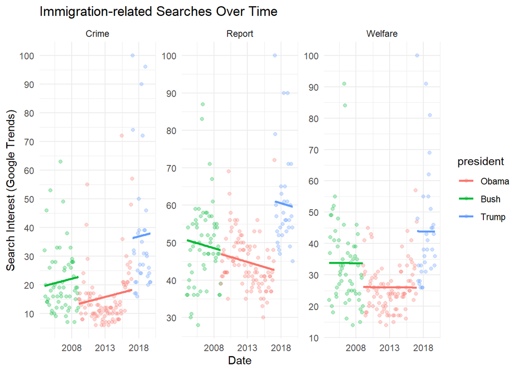

```r
combined_data$president <- relevel(factor(combined_data$president), ref = "Obama")

# Define the linear model function
run_regression <- function(data) {
  lm(hits ~ date + president, data = data)
}

# Run regression for each category
crime_model <- run_regression(filter(combined_data, terms == "Crime"))
welfare_model <- run_regression(filter(combined_data, terms == "Welfare"))
report_model <- run_regression(filter(combined_data, terms == "Report"))


combined_data <- combined_data %>%
  mutate(
    fitted_hits = case_when(
      terms == "Crime" ~ predict(crime_model, newdata = .),
      terms == "Welfare" ~ predict(welfare_model, newdata = .),
      terms == "Report" ~ predict(report_model, newdata = .)
    )
  )


ggplot(combined_data, aes(x = date, y = hits, color = president)) +
  geom_point(alpha = 0.3) +
  geom_line(aes(y = fitted_hits), size = 1) +
  facet_wrap(~ terms, scales = "free_y") +
  labs(title = "Immigration-related Searches Over Time",
       x = "Date",
       y = "Search Interest (Google Trends)") +
  theme_minimal() +
  scale_x_date(date_breaks = "5 years", date_labels = "%Y") +
  scale_y_continuous(n.breaks = 10)
```

The graph Prediction of term “Immigrants + Crime” over the years looks different compared to the one in paper since it predicts number of searches under Bush’s and Trump’s presidential terms as slightly upward trend while the paper shows number of searches shows downward trend in Bush and Trump’s term.

The graph Prediction of term “Immigrants + Welfare” over the years shows no significant upward or downward trends while the one in paper shows a negative trend during Bush term and positive trend during Trump term.

The graph Prediction of term “Immigrants + Reporting” over the years shows a slightly downward trend during Bush term while the one in the paper shows upward trend.

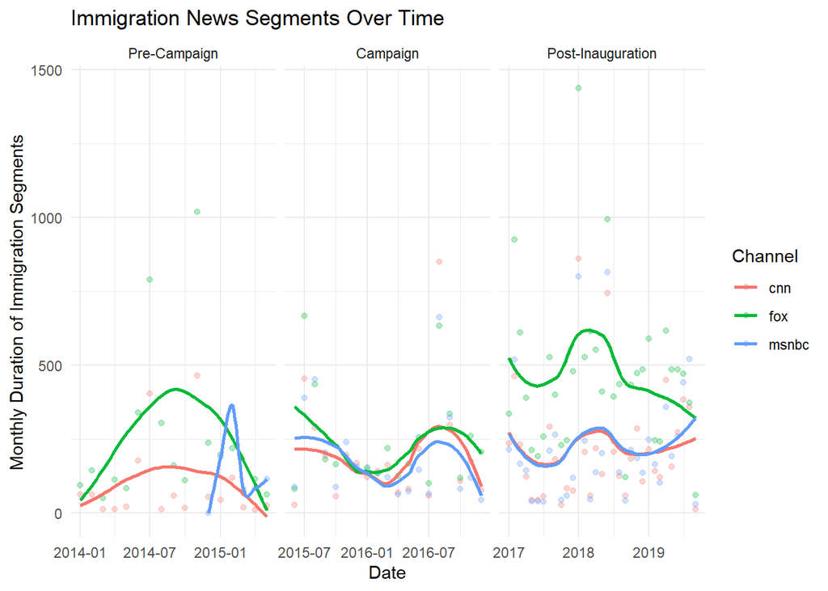

```r
library(data.table)
library(stm)
load("TopicModel.RData")

document_topics <- make.dt(immigrFit, meta = out$meta)

topic_terms <- t(exp(immigrFit$beta$logbeta[[1]]))

rownames(topic_terms) <- out$vocab

colnames(topic_terms) <- sprintf("Topic%d", 1:ncol(topic_terms))

# Convert date to Date type
document_topics$date <- as.Date(document_topics$date)

# Define periods and set the order
document_topics <- document_topics %>%
  mutate(period = case_when(
    date < as.Date("2015-06-01") ~ "Pre-Campaign",
    date >= as.Date("2015-06-01") & date < as.Date("2017-01-01") ~ "Campaign",
    date >= as.Date("2017-01-01") ~ "Post-Inauguration"
  )) %>%
  mutate(period = factor(period, levels = c("Pre-Campaign", "Campaign", "Post-Inauguration")))

# Aggregate the data by channel and month
aggregated_data <- document_topics %>%
  mutate(month = format(date, "%Y-%m")) %>%
  group_by(month, channel, period) %>%
  summarize(duration = sum(duration, na.rm = TRUE)) %>%
  ungroup()

# Convert month back to Date type for plotting
aggregated_data$month <- as.Date(paste0(aggregated_data$month, "-01"))

# Plot the results
ggplot(aggregated_data, aes(x = month, y = duration, color = channel)) +
  geom_point(alpha = 0.3) +
  geom_smooth(method = "loess", se = FALSE) +
  facet_wrap(~ period, scales = "free_x") +
  labs(title = "Immigration News Segments Over Time",
       y = "Monthly Duration of Immigration Segments", x = "Date", color = "Channel") +
  theme_minimal()
```

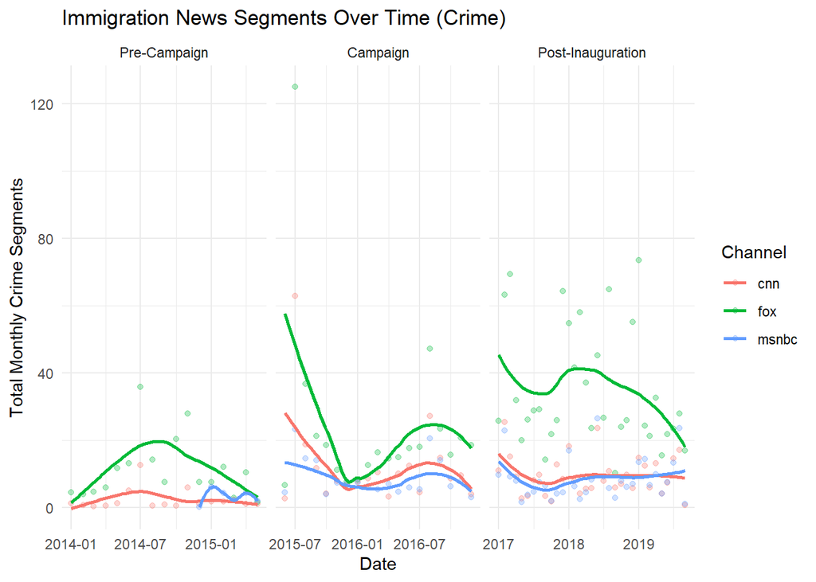

```r
# Define crime and welfare topics
crime_topics <- c("Topic1", "Topic3")
welfare_topic <- "Topic13"

# Define periods
document_topics <- document_topics %>%
  mutate(period = case_when(
    date < as.Date("2015-06-01") ~ "Pre-Campaign",
    date >= as.Date("2015-06-01") & date < as.Date("2017-01-01") ~ "Campaign",
    date >= as.Date("2017-01-01") ~ "Post-Inauguration"
  )) %>%
  mutate(period = factor(period, levels = c("Pre-Campaign", "Campaign", "Post-Inauguration")))

# Aggregate the data by channel, month, and topic
crime_data <- document_topics %>%
  mutate(month = format(date, "%Y-%m")) %>%
  group_by(month, channel, period) %>%
  summarize(crime_segments = sum(across(all_of(crime_topics)), na.rm = TRUE)) %>%
  ungroup()

welfare_data <- document_topics %>%
  mutate(month = format(date, "%Y-%m")) %>%
  group_by(month, channel, period) %>%
  summarize(welfare_segments = sum(across(all_of(welfare_topic)), na.rm = TRUE)) %>%
  ungroup()

# Convert month back to Date type for plotting
crime_data$month <- as.Date(paste0(crime_data$month, "-01"))
welfare_data$month <- as.Date(paste0(welfare_data$month, "-01"))

# Plot crime data
crime_plot <- ggplot(crime_data, aes(x = month, y = crime_segments, color = channel)) +
  geom_point(alpha = 0.3) +
  geom_smooth(method = "loess", se = FALSE) +
  facet_wrap(~ period, scales = "free_x") +
  labs(title = "Immigration News Segments Over Time (Crime)",
       y = "Total Monthly Crime Segments", x = "Date", color = "Channel") +
  theme_minimal()

# Plot welfare data
welfare_plot <- ggplot(welfare_data, aes(x = month, y = welfare_segments, color = channel)) +
  geom_point(alpha = 0.3) +
  geom_smooth(method = "loess", se = FALSE) +
  facet_wrap(~ period, scales = "free_x") +
  labs(title = "Immigration News Segments Over Time (Welfare)",
       y = "Total Monthly Welfare Segments", x = "Date", color = "Channel") +
  theme_minimal()

# Print plots
print(crime_plot)
```

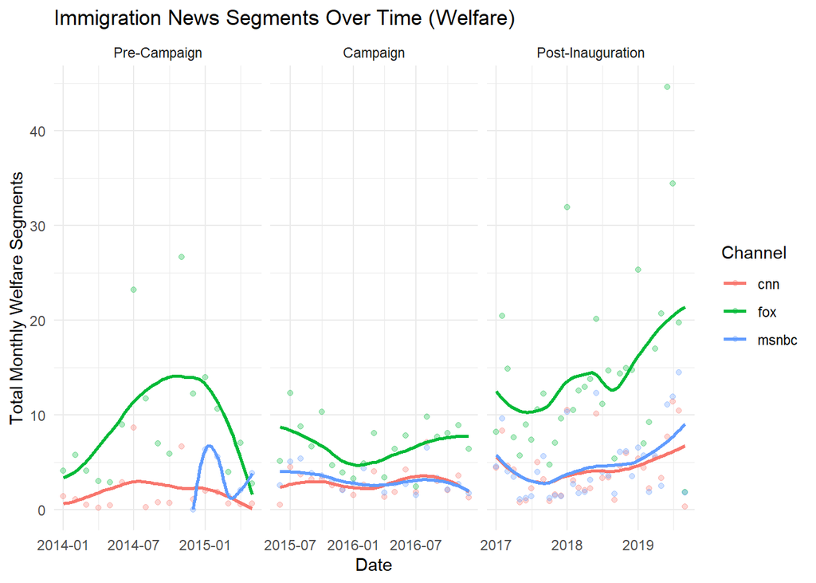

```r
print(welfare_plot)
```

This is the monthly version. The 3 plots look similar to Figure 2 and 3 used in the paper

```r
# Read and process the monthly data
report_immigrants <- read_csv("google_trends_report.csv") %>%
  mutate(
    date = as.Date(paste0(year, "-", month, "-01")),
    month = format(date, "%Y-%m"),
    hits = as.numeric(search),
    president = sapply(date, assign_president)
  )

# Aggregate the document topics data by month
aggregated_data <- document_topics %>%
  mutate(month = factor(format(date, "%Y-%m"))) %>%
  group_by(month) %>%
  summarize(
    duration = sum(duration, na.rm = TRUE),
    crime_coverage = sum(Topic1 + Topic3, na.rm = TRUE),
    welfare_coverage = sum(Topic13, na.rm = TRUE)
  )

# Merge aggregated data with report_immigrants data
merged_data <- report_immigrants %>%
  inner_join(aggregated_data, by = "month")

# Add dummy variables for Trump administration and Date
merged_data <- merged_data %>%
  mutate(trump_admin = ifelse(president == "Trump", 1, 0),
         date_numeric = as.numeric(date))

# Run regression on monthly data
monthly_model <- lm(hits ~ duration + crime_coverage + welfare_coverage + trump_admin + date_numeric, data = merged_data)

# Extract results
monthly_results <- tidy(monthly_model) %>%
  filter(term %in% c("(Intercept)", "duration", "crime_coverage", "welfare_coverage", "trump_admin", "date_numeric")) %>%
  mutate(term = case_when(
    term == "(Intercept)" ~ "Constant",
    term == "duration" ~ "Immigration segs",
    term == "crime_coverage" ~ "Immigr + Crime coverage",
    term == "welfare_coverage" ~ "Immigr + Welfare coverage",
    term == "trump_admin" ~ "Trump admin",
    term == "date_numeric" ~ "Date",
    TRUE ~ term
  ))

# Format the table using gt
monthly_results %>%
  gt() %>%
  tab_header(
    title = "Media Coverage and Reporting Searches (Google) - Monthly Data"
  ) %>%
  cols_label(
    term = "Dependent variable",
    estimate = "Estimate",
    std.error = "Std. Error",
    statistic = "t value",
    p.value = "p value"
  ) %>%
  fmt_number(
    columns = c(estimate, std.error, statistic, p.value),
    decimals=3)
```

Media Coverage and Reporting Searches (Google) - Monthly Data

| Dependent variable | Estimate | Std. Error | t value | p value |
| --- | --- | --- | --- | --- |
| Constant | 113.948 | 62.256 | 1.830 | 0.072 |
| Immigration segs | 0.001 | 0.004 | 0.253 | 0.801 |
| Immigr + Crime coverage | 0.080 | 0.048 | 1.644 | 0.105 |
| Immigr + Welfare coverage | 0.299 | 0.152 | 1.968 | 0.054 |
| Trump admin | 18.253 | 4.403 | 4.146 | 0.000 |
| Date | −0.005 | 0.004 | −1.255 | 0.214 |

```r
summary(monthly_model)
```

```
##
## Call:
## lm(formula = hits ~ duration + crime_coverage + welfare_coverage +
##     trump_admin + date_numeric, data = merged_data)
##
## Residuals:
##      Min       1Q   Median       3Q      Max
## -19.1746  -5.9912  -0.6451   3.5978  29.6352
##
## Coefficients:
##                    Estimate Std. Error t value Pr(>|t|)
## (Intercept)       1.139e+02  6.226e+01   1.830 0.071933 .
## duration          9.615e-04  3.807e-03   0.253 0.801415
## crime_coverage    7.966e-02  4.845e-02   1.644 0.105110
## welfare_coverage  2.992e-01  1.520e-01   1.968 0.053504 .
## trump_admin       1.825e+01  4.403e+00   4.146 0.000103 ***
## date_numeric     -4.727e-03  3.766e-03  -1.255 0.214052
## ---
## Signif. codes:  0 '***' 0.001 '**' 0.01 '*' 0.05 '.' 0.1 ' ' 1
##
## Residual standard error: 9.161 on 63 degrees of freedom
## Multiple R-squared:  0.5997, Adjusted R-squared:  0.568
## F-statistic: 18.88 on 5 and 63 DF,  p-value: 2.013e-11
```

This is generated by the daily data

```r
daily_data <- read_csv("gt_report_daily.csv")

# Convert the date column to Date type
daily_data <- daily_data %>%
  mutate(date = as.Date(date, format = "%Y-%m-%d"))

# Add period information based on the date
daily_data <- daily_data %>%
  mutate(period = case_when(
    date < as.Date("2015-06-01") ~ "Pre-Campaign",
    date >= as.Date("2015-06-01") & date < as.Date("2017-01-01") ~ "Campaign",
    date >= as.Date("2017-01-01") ~ "Post-Inauguration"
  ))

# Ensure the period column is in the aggregated data
aggregated_data_daily <- aggregated_data %>%
  ungroup() %>%
  mutate(date = as.Date(paste0(month, "-01")),
         period = case_when(
           date < as.Date("2015-06-01") ~ "Pre-Campaign",
           date >= as.Date("2015-06-01") & date < as.Date("2017-01-01") ~ "Campaign",
           date >= as.Date("2017-01-01") ~ "Post-Inauguration"
         )) %>%
  select(date, duration, crime_coverage, welfare_coverage, period)

# Merge daily data with aggregated data
merged_daily_data <- daily_data %>%
  left_join(aggregated_data_daily, by = c("date", "period"))

# Add dummy variables for Trump administration and Date
merged_daily_data <- merged_daily_data %>%
  mutate(trump_admin = ifelse(date >= as.Date("2017-01-20"), 1, 0),
         date_numeric = as.numeric(date))

# Run regression on daily data
daily_model <- lm(search ~ duration + crime_coverage + welfare_coverage + trump_admin + date_numeric, data = merged_daily_data)

# Extract results
daily_results <- tidy(daily_model) %>%
  filter(term %in% c("duration", "crime_coverage", "welfare_coverage", "trump_admin", "date_numeric")) %>%
  mutate(term = case_when(
    term == "duration" ~ "Immigration segs",
    term == "crime_coverage" ~ "Immigr + Crime coverage",
    term == "welfare_coverage" ~ "Immigr + Welfare coverage",
    term == "trump_admin" ~ "Trump admin",
    term == "date_numeric" ~ "Date",
    TRUE ~ term
  ))

# Add the constant term
constant_term <- tidy(daily_model) %>%
  filter(term == "(Intercept)") %>%
  mutate(term = "Constant")

# Combine results with the constant term
daily_results <- bind_rows(daily_results, constant_term)

# Format the table using gt
daily_results %>%
  gt() %>%
  tab_header(
    title = "Media Coverage and Reporting Searches (Google) - Daily Data"
  ) %>%
  cols_label(
    term = "Dependent variable",
    estimate = "Estimate",
    std.error = "Std. Error",
    statistic = "t value",
    p.value = "p value"
  ) %>%
  fmt_number(
    columns = c(estimate, std.error, statistic, p.value),
    decimals = 3
  )
```

Media Coverage and Reporting Searches (Google) - Daily Data

| Dependent variable | Estimate | Std. Error | t value | p value |
| --- | --- | --- | --- | --- |
| Immigration segs | −0.006 | 0.008 | −0.677 | 0.501 |
| Immigr + Crime coverage | 0.210 | 0.106 | 1.988 | 0.051 |
| Immigr + Welfare coverage | 0.012 | 0.331 | 0.037 | 0.971 |
| Trump admin | 0.598 | 9.596 | 0.062 | 0.951 |
| Date | −0.006 | 0.008 | −0.706 | 0.483 |
| Constant | 141.278 | 135.685 | 1.041 | 0.302 |

### Introduction

In this analysis, we aimed to explore how other specific immigration-related topics, beside the immigration crime and welfare had an impact on reporting searches. By setting thresholds to identify topics with significant wave patterns, we highlighted topics 17, 19, 20, and 27 as particularly noteworthy. Subsequently, we conducted a regression analysis to determine their statistical significance.

### Approach

We aggregated the document topics data by month and merged it with the report immigrants data to facilitate our regression analysis. The data included various immigration-related topics and their coverage duration.

```r
# Aggregate the data by channel, month, and topic
aggregated_data <- document_topics %>%
  mutate(month = format(date, "%Y-%m")) %>%
  pivot_longer(cols = starts_with("Topic"), names_to = "topic", values_to = "value") %>%
  group_by(month, topic, period) %>%
  summarize(total_value = sum(value, na.rm = TRUE)) %>%
  ungroup()

# Convert month back to Date type for plotting
aggregated_data$month <- as.Date(paste0(aggregated_data$month, "-01"))
```

We set some thresholds to identify topics with significant wave pattern, and then plot them out.

```r
# Calculate the range for each topic
topic_ranges <- aggregated_data %>%
  group_by(topic) %>%
  summarize(range = max(total_value) - min(total_value))

# Define a threshold for significant fluctuations
threshold <- 150  # This can be adjusted based on your requirements

# Filter topics with significant fluctuations
significant_topics <- topic_ranges %>%
  filter(range > threshold & range <500) %>%
  pull(topic)

# Filter the aggregated data to include only significant topics
significant_data <- aggregated_data %>%
  filter(topic %in% significant_topics)
```

In this part, we identify new topic trends during the campaign and Post-Inauguration part, which will be the focus of our research analysis.

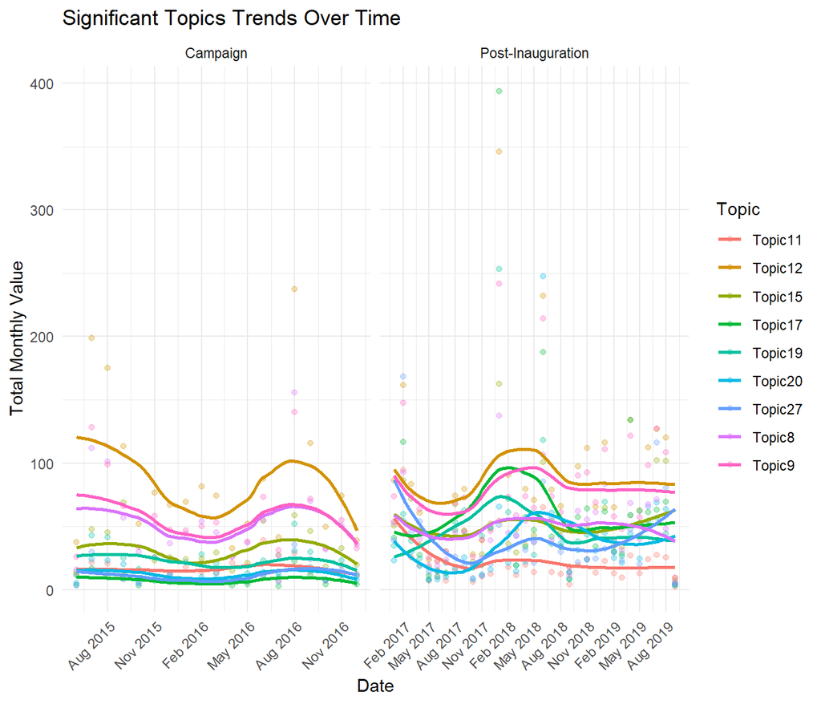

```r
# Plot the results for significant topics
# Filter for Campaign and Post-Inauguration periods only
filtered_data <- significant_data %>%
  filter(period %in% c("Campaign", "Post-Inauguration"))

# Plot the data with specific date breaks and labels
ggplot(filtered_data, aes(x = month, y = total_value, color = topic)) +
  geom_point(alpha = 0.3) +
  geom_smooth(method = "loess", se = FALSE) +
  facet_wrap(~ period, scales = "free_x") +
  labs(title = "Significant Topics Trends Over Time",
       y = "Total Monthly Value", x = "Date", color = "Topic") +
  theme_minimal() +
  scale_x_date(date_breaks = "3 months", date_labels = "%b %Y")+
  theme(axis.text.x = element_text(angle = 45, hjust = 1))
```

Out of all emerging topics, we decide to explore topic 17, 19, 20, 27. We decide to exclude topics that were discussed in the main paper and topics that are simply common terms used in election process.

### Regression Analysis

The regression analysis aimed to determine the impact of various factors, including the identified topics, on the number of hits related to reporting searches.

```r
# Aggregate the document topics data by month
aggregated_data <- document_topics %>%
  mutate(month = factor(format(date, "%Y-%m"))) %>%
  group_by(month) %>%
  summarize(
    duration = sum(duration, na.rm = TRUE),
    crime_coverage = sum(Topic1 + Topic3, na.rm = TRUE),
    welfare_coverage = sum(Topic13, na.rm = TRUE),
    Topic_17 = sum(Topic17, na.rm = TRUE),
    Topic_19 = sum(Topic19, na.rm = TRUE),
    Topic_20 = sum(Topic20, na.rm = TRUE),
    Topic_27 = sum(Topic27, na.rm = TRUE)
  )

# Merge aggregated data with report_immigrants data
merged_data <- report_immigrants %>%
  inner_join(aggregated_data, by = "month")

# Add dummy variables for Trump administration and Date
merged_data <- merged_data %>%
  mutate(trump_admin = ifelse(president == "Trump", 1, 0),
         date_numeric = as.numeric(date))

# Run regression on monthly data
monthly_model <- lm(hits ~ duration + Topic_17 + Topic_19 + Topic_20 + Topic_27 + crime_coverage + welfare_coverage + trump_admin + date_numeric, data = merged_data)

# Extract results
monthly_results <- tidy(monthly_model) %>%
  filter(term %in% c("(Intercept)", "duration", "crime_coverage", "welfare_coverage", "Topic_17", "Topic_19", "Topic_20", "Topic_27", "trump_admin", "date_numeric")) %>%
  mutate(term = case_when(
    term == "(Intercept)" ~ "Constant",
    term == "duration" ~ "Immigration segs",
    term == "crime_coverage" ~ "Immigr + Crime coverage",
    term == "welfare_coverage" ~ "Immigr + Welfare coverage",
    term == "Topic_17" ~ "Topic_17",
    term == "Topic_19" ~ "Topic_19",
    term == "Topic_20" ~ "Topic_20",
    term == "Topic_27" ~ "Topic_27",
    term == "trump_admin" ~ "Trump admin",
    term == "date_numeric" ~ "Date",
    TRUE ~ term
  ))

# Format the table using gt
monthly_results %>%
  gt() %>%
  tab_header(
    title = "Media Coverage and Reporting Searches (Google) - Monthly Data"
  ) %>%
  cols_label(
    term = "Dependent variable",
    estimate = "Estimate",
    std.error = "Std. Error",
    statistic = "t value",
    p.value = "p value"
  ) %>%
  fmt_number(
    columns = c(estimate, std.error, statistic, p.value),
    decimals = 3
  )
```

Media Coverage and Reporting Searches (Google) - Monthly Data

| Dependent variable | Estimate | Std. Error | t value | p value |
| --- | --- | --- | --- | --- |
| Constant | 67.066 | 54.031 | 1.241 | 0.219 |
| Immigration segs | −0.013 | 0.006 | −2.344 | 0.022 |
| Topic_17 | −0.012 | 0.062 | −0.202 | 0.840 |
| Topic_19 | 0.171 | 0.124 | 1.383 | 0.172 |
| Topic_20 | 0.122 | 0.044 | 2.780 | 0.007 |
| Topic_27 | 0.289 | 0.071 | 4.077 | 0.000 |
| Immigr + Crime coverage | 0.091 | 0.046 | 1.965 | 0.054 |
| Immigr + Welfare coverage | −0.099 | 0.158 | −0.626 | 0.534 |
| Trump admin | 10.130 | 4.190 | 2.418 | 0.019 |
| Date | −0.002 | 0.003 | −0.513 | 0.610 |

```r
summary(monthly_model)
```

```
##
## Call:
## lm(formula = hits ~ duration + Topic_17 + Topic_19 + Topic_20 +
##     Topic_27 + crime_coverage + welfare_coverage + trump_admin +
##     date_numeric, data = merged_data)
##
## Residuals:
##     Min      1Q  Median      3Q     Max
## -13.503  -4.174  -1.086   3.732  25.596
##
## Coefficients:
##                   Estimate Std. Error t value Pr(>|t|)
## (Intercept)      67.066406  54.030977   1.241 0.219423
## duration         -0.013448   0.005736  -2.344 0.022447 *
## Topic_17         -0.012492   0.061784  -0.202 0.840462
## Topic_19          0.170986   0.123609   1.383 0.171792
## Topic_20          0.122429   0.044032   2.780 0.007274 **
## Topic_27          0.289321   0.070964   4.077 0.000138 ***
## crime_coverage    0.090547   0.046087   1.965 0.054165 .
## welfare_coverage -0.098893   0.157972  -0.626 0.533720
## trump_admin      10.129867   4.189722   2.418 0.018722 *
## date_numeric     -0.001680   0.003275  -0.513 0.609872
## ---
## Signif. codes:  0 '***' 0.001 '**' 0.01 '*' 0.05 '.' 0.1 ' ' 1
##
## Residual standard error: 7.677 on 59 degrees of freedom
## Multiple R-squared:  0.7368, Adjusted R-squared:  0.6966
## F-statistic: 18.35 on 9 and 59 DF,  p-value: 4.395e-14
```

The regression analysis revealed that topics 20 and 27 had significant coefficients, suggesting a notable influence on the dependent variable.

### Key Findings

Topic 20: Family Separation and Zero Tolerance Policy Highest Prob: family, children, separation, parent, kid, child, one FREX: reunite, parent, children, separation, kid, mother, zero Score: children, family, separation, parent, kid, child, mother The significant keywords in Topic 20 strongly correlate with the “Trump zero tolerance policy + separation.” Our regression analysis confirmed the substantial impact of this topic during the Trump administration.

Topic 27: ICE Deportation Highest Prob: ice, deport, enforce, criminal, undocumented, agent, arrest FREX: custom, raid, ice, abolish, remove, operation, agency Score: ice, raid, custom, agent, deport, arrest, enforce Topic 27, characterized by keywords related to ICE and deportation, aligns with “ICE deportation” search trends, indicating heightened media coverage and public interest during relevant political events.

Topic 27, characterized by keywords related to ICE and deportation, aligns with “ICE deportation” search trends, indicating heightened media coverage and public interest during relevant political events.

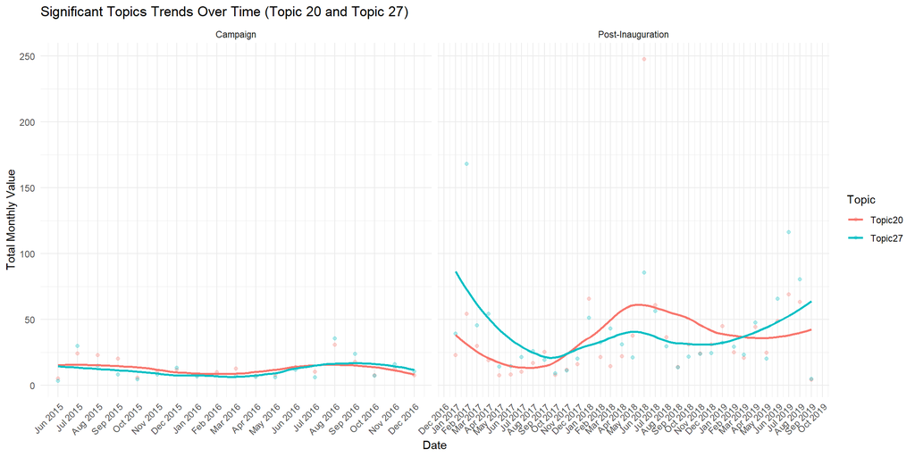

```r
# Filter for Campaign and Post-Inauguration periods only, and include only Topic 20 and Topic 27
filtered_data <- significant_data %>%
  filter(period %in% c("Campaign", "Post-Inauguration") & topic %in% c("Topic20", "Topic27"))

# Plot the data with specific date breaks and labels
ggplot(filtered_data, aes(x = month, y = total_value, color = topic)) +
  geom_point(alpha = 0.3) +
  geom_smooth(method = "loess", se = FALSE) +
  facet_wrap(~ period, scales = "free_x") +
  labs(title = "Significant Topics Trends Over Time (Topic 20 and Topic 27)",
       y = "Total Monthly Value", x = "Date", color = "Topic") +
  theme_minimal() +
  scale_x_date(date_breaks = "1 month", date_labels = "%b %Y") +
  theme(axis.text.x = element_text(angle = 45, hjust = 1))
```

We realize there are more upticks in topic 20 and topic 27 during Post-Inauguration period.

### Supplementary Analysis

Zero Tolerance Policy

```r
# Read the data without any transformations
zero_tolerance_raw <- read_csv("zero_tolerance_policy.csv", skip = 2, col_names = c("Week", "trump_zero_tolerance_separ"))
print(head(zero_tolerance_raw))
```

```
## # A tibble: 6 × 2
##   Week       trump_zero_tolerance_separ
##   <chr>      <chr>
## 1 Week       trump zero tolerance + separ: (United States)
## 2 2015-06-28 0
## 3 2015-07-05 0
## 4 2015-07-12 0
## 5 2015-07-19 0
## 6 2015-07-26 0
```

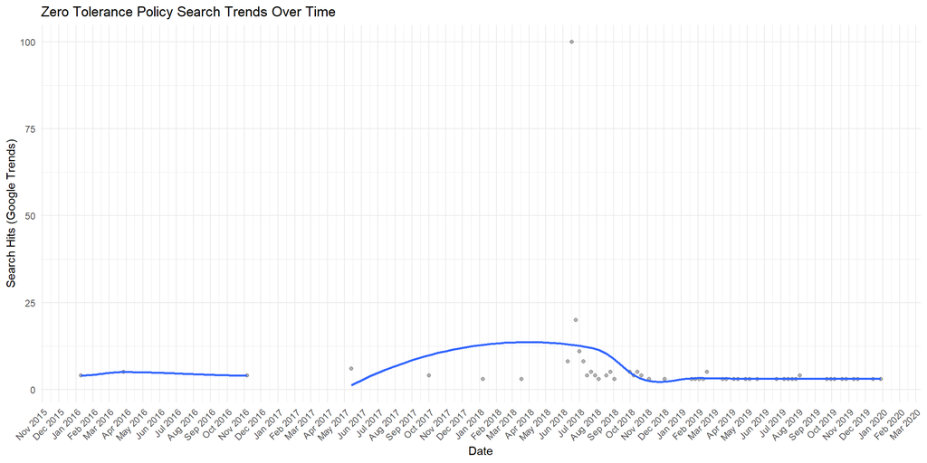

```r
# Load and preprocess the data
zero_tolerance_policy <- zero_tolerance_raw %>%
  mutate(
    date = ymd(Week),  # Use lubridate's ymd to parse the date
    hits = as.numeric(trump_zero_tolerance_separ),
    terms = "zero_tolerance_policy"
  ) %>%
  filter(!is.na(date) & hits > 0) %>%
  mutate(president = sapply(date, assign_president)) %>%
  mutate(period = case_when(
    date < as.Date("2015-06-01") ~ "Pre-Campaign",
    date >= as.Date("2015-06-01") & date < as.Date("2017-01-01") ~ "Campaign",
    date >= as.Date("2017-01-01") ~ "Post-Inauguration"
  )) %>%
  mutate(period = factor(period, levels = c("Pre-Campaign", "Campaign", "Post-Inauguration")))

# Plot the trends over the date
ggplot(zero_tolerance_policy, aes(x = date, y = hits, group = period)) +
  geom_point(alpha = 0.3) +
  geom_smooth(method = "loess", se = FALSE) +
  labs(title = "Zero Tolerance Policy Search Trends Over Time",
       x = "Date", y = "Search Hits (Google Trends)", color = "Period") +
  theme_minimal() +
  scale_x_date(date_breaks = "1 months", date_labels = "%b %Y") +
  theme(axis.text.x = element_text(angle = 45, hjust = 1))
```

From the set of key words included in the topic 20, we can identify that the search trend for Trump’s “zero tolerance policy” also correlates with the trend of reporting searches.

```r
# Read the data without any transformations
ice_deportation_raw <- read_csv("ICEdeportation.csv", skip = 2, col_names = c("Week", "ICE_deportation"))
print(head(ice_deportation_raw))
```

```
## # A tibble: 6 × 2
##   Week       ICE_deportation
##   <chr>      <chr>
## 1 Week       ICE deportation: (United States)
## 2 2015-06-28 0
## 3 2015-07-05 0
## 4 2015-07-12 0
## 5 2015-07-19 0
## 6 2015-07-26 0
```

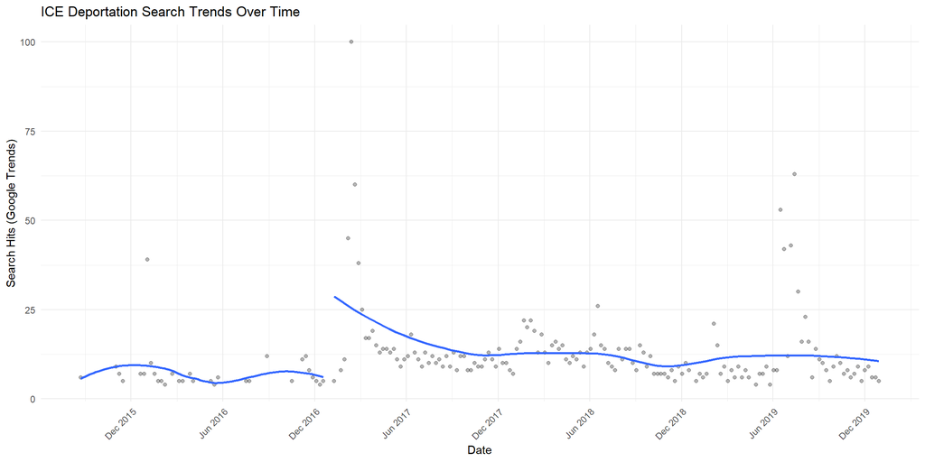

```r
# Load and preprocess the data
ice_deportation_policy <- ice_deportation_raw %>%
  mutate(
    date = ymd(Week),  # Use lubridate's ymd to parse the date
    hits = as.numeric(ICE_deportation),
    terms = "ICE_deportation"
  ) %>%
  filter(!is.na(date) & hits > 0) %>%
  mutate(president = sapply(date, assign_president)) %>%
  mutate(period = case_when(
    date < as.Date("2015-06-01") ~ "Pre-Campaign",
    date >= as.Date("2015-06-01") & date < as.Date("2017-01-01") ~ "Campaign",
    date >= as.Date("2017-01-01") ~ "Post-Inauguration"
  )) %>%
  mutate(period = factor(period, levels = c("Pre-Campaign", "Campaign", "Post-Inauguration")))

# Plot the trends over the date
ggplot(ice_deportation_policy, aes(x = date, y = hits, group = period)) +
  geom_point(alpha = 0.3) +
  geom_smooth(method = "loess", se = FALSE) +
  labs(title = "ICE Deportation Search Trends Over Time",
       x = "Date", y = "Search Hits (Google Trends)", color = "Period") +
  theme_minimal() +
  scale_x_date(date_breaks = "6 months", date_labels = "%b %Y") +
  theme(axis.text.x = element_text(angle = 45, hjust = 1))
```

From the set of key words included in the topic 27, we can identify that the search trend for ICE deportation event also correlates with the reporting searches trend.

### Conclution

We observed overlapping trends between political events and reporting searches during Post-inauguration. These findings were suppported by analyzing Google trend data of topic 20 and 27’s keywords.

By plotting the trends over time, we were able to identify that there are political events happening during Post that can influence the reporting searches.

Future research could explore (1) the long-term effect of Trump presidency on media coverage regarding immigrant policy, (2) including more news channel from different political spectrum to decrease selection bias.